# Predicting Drug Use Using Personailty Type and Pyschological Diagnoses- Summer 2026

A comparasion between MLP and RNN on non-sequential data

Elizabeth Rose and Victoria Kipker (Advisor: Dr. Cohen)

2026-07-22

## Introduction

### Navigating the Modern Crisis:

- Current mental health crisis accelerated by socioeconomic challenges and cognitive overload
- Coping mechanisms or methods of escape are enticing
- Many turn to unregulated online sources, such as social media or AI, for self-diagnosis and self-medication
- Available drugs are ever-evolving
- Individuals are essentially overwhelmed by choice

## Our Goal

- To determine if personality type is a good indicator for an individual’s substance of choice
- If personality is a good indicator, can a model be used to identify “at-risk” individuals in a way that does not consider use of different substances to be mutually exclusive?

## Methods

We will compare a traditional Artificial Neural Network, a multilayer perceptron (MLP) model, to a recurrent neural network (RNN) to see which model can better predict substance use from personality type.

## MLP

- Standard feed-forward architecture for structured, tabular data
- Information flows in one direction
- Neurons within same layer are not interconnected
- Not the most advanced, but has remained the benchmark when simplicity and efficiency are needed

(El-Mandouh et al. 2026) (Przybyła-Kasperek and Marfo 2024)

## RNN

- Typically used for time series data
- Incorporates short-term memory
- Allows information to propagate through feedback loops
- Neurons within same layer are interconnected
- Model can maintain context across a sequence to link current and historical information

(El-Mandouh et al. 2026)

## Model Specifications

### MLP

- Input layer, 2 hidden layers, and 1 output layer
  - First hidden layer: 64 neurons with Rectified Linear Unit (ReLU) activation
  - Second hidden layer: 32 neurons with ReLU activation
  - Output layer: 15 neurons with sigmoid activation (important for multi-label classification)

### RNN

- Input layer, 1 hidden layer, and 1 output layer
  - Hidden layer: limited short-term memory (LSTM) layer of 64 neurons
  - Output layer: 15 neurons and a sigmoid activation function

## Classification threshold

- For both models, a dynamic threshold using the base use rate was used as our classification threshold.
- e.g. if a drug had a use rate of 10% in the dataset and the predicted probability is .11, that is classified as a 1 (user)
- We also tried median and mean dynamic thresholds with less success (lower recall and precision)

## Data Collection

- Data collected via an online survey by Fehrman et al.
- Survey included questions on drug use (18 legal and illegal substances), frequency of drug use, personality traits, and demographic information
- Personality trait information collected using Revised NEO Five-Factor Inventory, Barratt Impulsiveness Scale, and Impulsive Sensation Seeking scale
- Initially yielded results from 2,051 respondents (final sample size was 1,885)
- Majority of respondents were from the UK (55.4%) and the US (29.5%)
- Included fictitious drug “Semeron” as a validity check.

(Fehrman et al. 2017)

## Variables

Personality trait and drug use features collected by Fehrman et al. (Fehrman et al. 2017) via online survey

| **Variable Name** | **Description** |
| --- | --- |
| nscore | Neuroticism score |
| escore | Extraversion score |
| oscore | Openness to Experience score |
| ascore | Agreeableness score |
| cscore | Conscientiousness score |
| impuslive | Impulsiveness (BIS-11) score |
| ss | Sensation Seeking (ImpSS) score |
| alcohol | Alcohol usage frequency (1-7) |
| amphet | Amphetamine usage frequency (1-7) |
| amyl | Amyl nitrite usage frequency (1-7) |
| benzos | Benzodiazepine usage frequency (1-7) |
| caff | Caffeine usage frequency (1-7) |
| cannabis | Cannabis usage frequency (1-7) |
| choc | Chocolate usage frequency (1-7) |
| coke | Cocaine usage frequency (1-7) |
| crack | Crack usage frequency (1-7) |
| ecstasy | Ecstasy usage frequency (1-7) |
| heroin | Heroin usage frequency (1-7) |
| ketamine | Ketamine usage frequency (1-7) |
| legalh | Legal highs usage frequency (1-7) |
| lsd | LSD usage frequency (1-7) |
| meth | Methadone usage frequency (1-7) |
| mushrooms | Magic mushrooms usage frequency (1-7) |
| nicotine | Nicotine usage frequency (1-7) |
| semer | Semeron (ficticious drug) usage frequency (1-7) |
| vsa | Volatile Substance Abuse usage frequency (1-7) |

## Data Exploration and Visualization

Visual of class imbalance: Figure 1

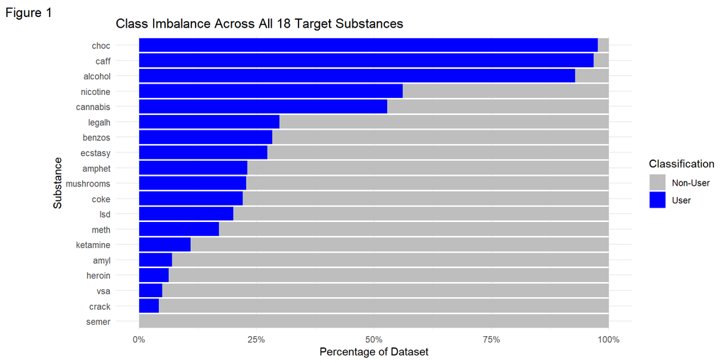

## Psychological footprints

Similarities noticed between polygons hints at correlation of substances

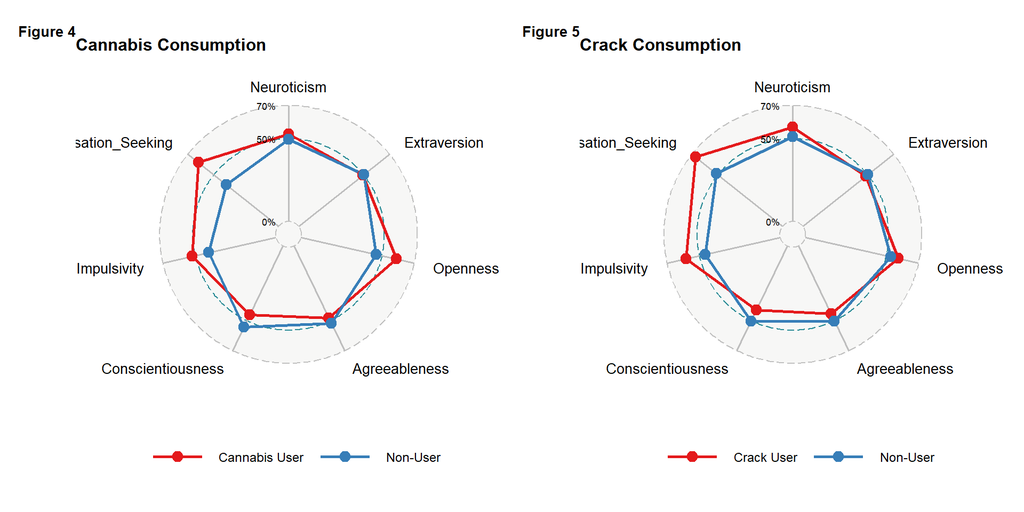

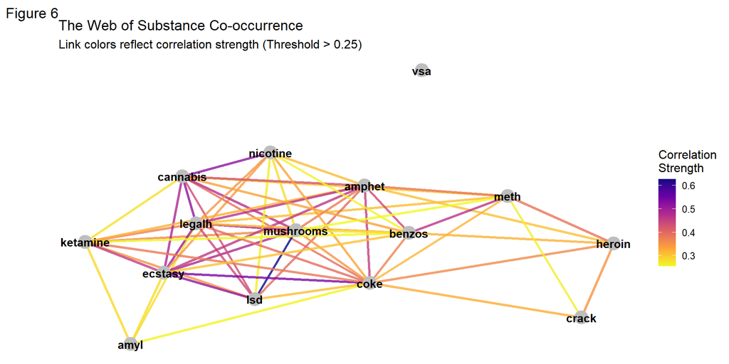

## Preprocessing

#### Performed by original researchers:

- Personality scores were quantified to continuous variables that approximate standard normal distribution
- Removal of incomplete/unusable respondent data
- Removal of data from individuals that claimed “semeron” use

#### Performed prior to our study:

- Binarization of “users” vs. “non-users” for each substance
  - Use within the past year was considered a “user”
- Removal of 3 most used substances (chocolate, caffeine, alcohol)
- For RNN model: converted the 2D matrices (for MLP) into 3D arrays
  - Created a sequential feature extractor

## The MLP

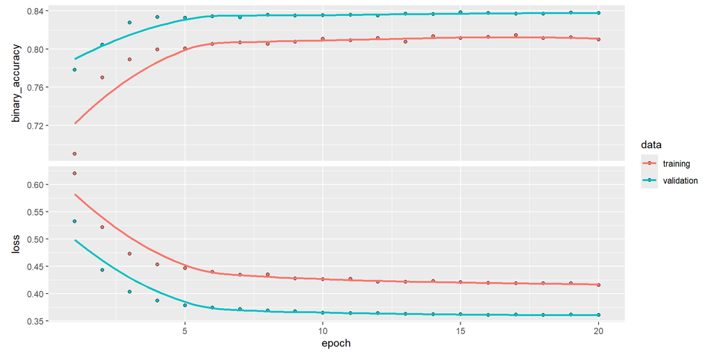

## Hit or miss?

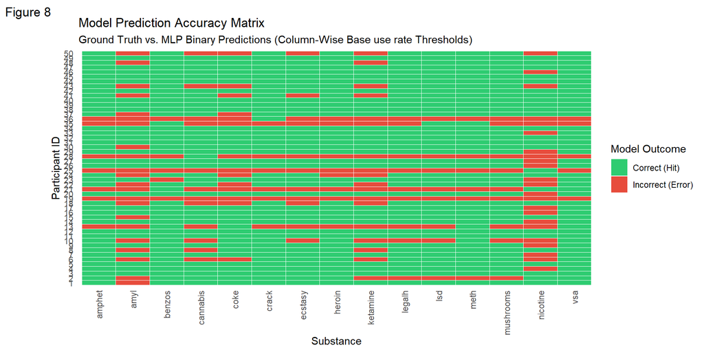

## The RNN

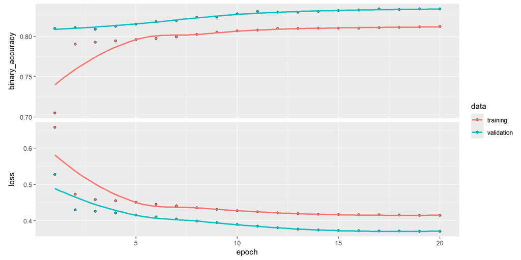

## MLP vs RNN

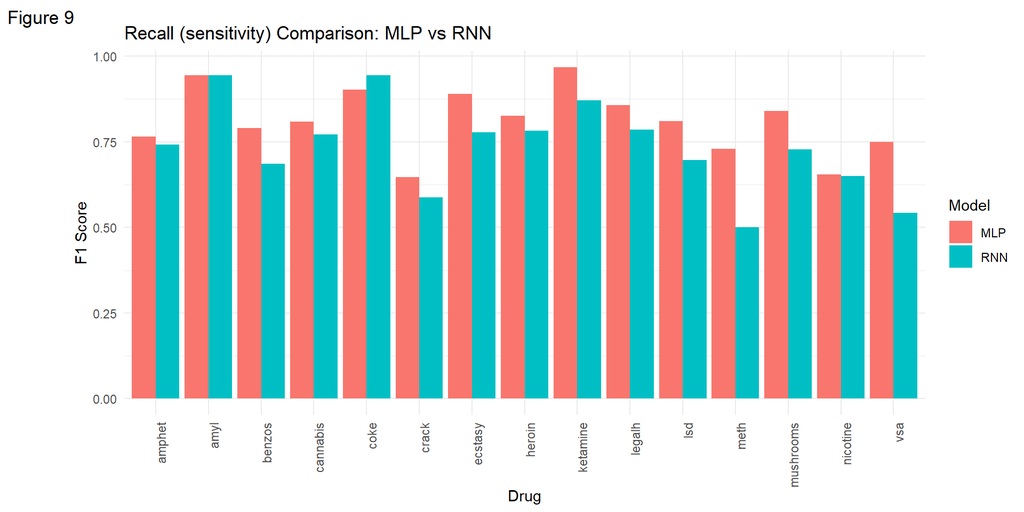

## Confusion!

```
=== Dynamic Thresholds (Base Usage Rates) ===
```

```
   amphet      amyl    benzos  cannabis      coke     crack   ecstasy    heroin
   0.2307    0.0703    0.2834    0.5280    0.2206    0.0421    0.2733    0.0629
 ketamine    legalh       lsd      meth mushrooms  nicotine       vsa
   0.1097    0.2989    0.2003    0.1700    0.2280    0.5610    0.0495
```

```
========================================
Confusion Matrix for: amphet
Threshold used: 0.2307
========================================
          Reference
Prediction   0   1
         0 175  20
         1 109  65
Sensitivity (Recall): 0.7647
Specificity: 0.6162
Balanced Accuracy: 0.6905

========================================
Confusion Matrix for: amyl
Threshold used: 0.0703
========================================
          Reference
Prediction   0   1
         0 153   3
         1 198  15
Sensitivity (Recall): 0.8333
Specificity: 0.4359
Balanced Accuracy: 0.6346

========================================
Confusion Matrix for: benzos
Threshold used: 0.2834
========================================
          Reference
Prediction   0   1
         0 166  22
         1  98  83
Sensitivity (Recall): 0.7905
Specificity: 0.6288
Balanced Accuracy: 0.7096

========================================
Confusion Matrix for: cannabis
Threshold used: 0.528
========================================
```

[output cut: 124 more lines]

```
Sensitivity (Recall): 0.6538
Specificity: 0.7081
Balanced Accuracy: 0.681

========================================
Confusion Matrix for: vsa
Threshold used: 0.0495
========================================
          Reference
Prediction   0   1
         0 204   4
         1 141  20
Sensitivity (Recall): 0.8333
Specificity: 0.5913
Balanced Accuracy: 0.7123
```

## Combined confusion matrix

```
Overall Model Performance (Dynamic Thresholds)
```

```
Confusion Matrix and Statistics

          Reference
Prediction    0    1
         0 2599  257
         1 1734  945

               Accuracy : 0.6403
                 95% CI : (0.6275, 0.6529)
    No Information Rate : 0.7828
    P-Value [Acc > NIR] : 1

                  Kappa : 0.2673

 Mcnemar's Test P-Value : <2e-16

            Sensitivity : 0.7862
            Specificity : 0.5998
         Pos Pred Value : 0.3527
         Neg Pred Value : 0.9100
             Prevalence : 0.2172
         Detection Rate : 0.1707
   Detection Prevalence : 0.4840
      Balanced Accuracy : 0.6930

       'Positive' Class : 1
```

## Conclusion

- Personality traits can be good indicators for substance usage risk when using ANN model frameworks
- Achieved overall binary accuracy rate of greater than 82% for both models
- Using adaptive base use rate threshold for classification caused precision to suffer, inflating number of false positives, improved with base use threshold
- MLP is overall more efficient/accurate for multi-label classification when compared to RNN
- RNN able to model complex relationships between personality data (cocaine)

## References

El-Mandouh, Mahmoud A., Hassan Youssef, M. S. Elborlsy, and Mostafa A. Ebied. 2026. “Comparing Machine Learning and Deep Learning Approaches to Predicting the Seismic Response of Slab-Column Connections.” *Scientific Reports* 16 (1): 14718. https://doi.org/10.1038/s41598-026-50962-9.

Fehrman, Elaine, Awaz Kakamam Muhammad, Evgeny M. Mirkes, Vincent Egan, and Alexander N. Gorban. 2017. “The Five Factor Model of Personality and Evaluation of Drug Consumption Risk.” In *Data Science: Innovative Developments in Data Analysis and Clustering*. Springer International Publishing. https://doi.org/10.1007/978-3-319-55723-6_18.

Przybyła-Kasperek, Małgorzata, and Kwabena Frimpong Marfo. 2024. “A Multi-Layer Perceptron Neural Network for Varied Conditional Attributes in Tabular Dispersed Data.” *PLoS ONE* 19 (12): e0311041. https://doi.org/10.1371/journal.pone.0311041.